# Assignments with R and Quarto

STA4173: Biostatistics

Author

Ranadeep Daw

Published

July 23, 2024

### Overview.

This guide has been adapted from [here](http://www.stat.cmu.edu/~cshalizi/rmarkdown). I am assuming that the reader is familiar with the interface of $\texttt{R}$ and has $\texttt{RStudio}$ installed. If not, please install both at [$\texttt{R}$](https://www.r-project.org) and [$\texttt{RStudio}$](https://posit.co/download/rstudio-desktop/).

### What is $\texttt{R}$ Markdown?

Markdown is a **mark-up** language invented by John Gruber. Technically, it is a front-end for HTML. It is now integrated in $\texttt{RStudio}$ (known as $\texttt{R}$-Markdown), which we will use to write reports in HTML or PDF formats. $\texttt{R}$-Markdown helps us include $\texttt{R}$ code and results directly into these reports.

**Note**, you may have to install Markdown in $\texttt{R}$ using the following code.

```r
install.packages('rmarkdown')
```

Note, to generate PDF output, you may need to install [TinyTeX](https://yihui.name/tinytex/):

```r
install.packages('tinytex')
tinytex::install_tinytex()  # install TinyTeX
```

### What is Quarto?

From the official Quarto [documentation](https://quarto.org/docs/computations/r.html), ``Quarto is a multi-language, next generation version of $\texttt{R}$-Markdown from RStudio, with many new features and capabilities.’’ There is a little difference between Quarto and Markdown systanx, but they won’t be important here. We will use Quarto to write Markdown in $\texttt{RStudio}$.

**Note:** 1. Quarto is now default available with $\texttt{RStudio}$. 2. If you directly want to use Quarto from $\texttt{R}$, install the package as the following:

```r
install.packages("quarto") # Do it only once to install
library(quarto)
quarto_render("document.qmd")
```

### Writing Markdown in $\texttt{R}$.

We will use $\texttt{RStudio}$ and Quarto Document. Note that, the Quarto files have extension $\texttt{.qmd}$. You can start with a new .qmd file by doing the following:

[figure not shown]

- File $\rightarrow$ New File $\rightarrow$ Quarto Document (see above).
- Choose html/pdf format for assignments (**please don’t use Word**).
- **Make sure** to uncheck the Editor: Use Visual Markdown Editor box.
- Click create. Then save it somewhere.

Note that, by unchecking the Visual Markdown Editor, you will see the Source editor as in the following image. If not, make sure to click on *Source*.

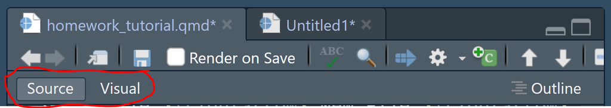

### Author Information

By default, you will see that the .qmd file has the following details on top:

```yaml
---
title: "Untitled"
format: html
---
```

This block is called the YAML block. Just edit the details here to have a block like this:

```yaml
---
title: "<<The assignment title, i.e., HW 2 or Project 1>>"
author: "<<Your name>>"
date: "today"
format: html
---
```

A more detailed tutorial is available at the official Quarto documentation [website](https://quarto.org/docs/projects/quarto-projects.html).

### Text and header of Markdown

- To write a section heading, use #, ##, $\cdots$, ######. For example, ### Section 1.
- To write any text after the header, just start typing. Some common $\texttt{HTML}$ and $\LaTeX$ syntaxes work for math typing.

### $\texttt{R}$ Code Chunks

For our purposes with assignments, you have to write $\texttt{R}$ code. This has to be written within the ```{r} and ``` environment. For example, to calculate the sum of the numbers from $1$ to $10$ in $\texttt{R}$, do the following:

````markdown
```{r}
1 + 2 + 3 + 4 + 5 + 6 + 7 + 8 + 9 + 10
```
````

[figure not shown]

Alternatively, there is an insert chunk button on RStudio toolbar as shown above. **Note,** to test one code chunk, please click on the green right arrow beside the ```{r} line.

### Attaching an image

Use an exclamation mark, followed by a text to use if the image is not available, followed by the file address of the image.

```html
![Text if image not available](C:/images/result1.png)
```

### Rendering the output

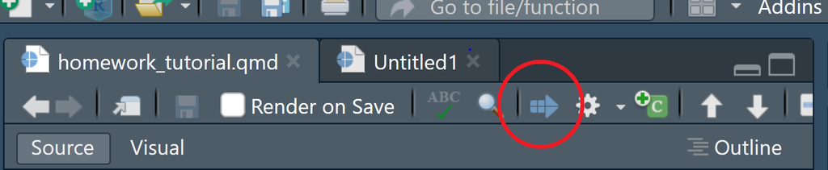

Click on the render button (see above) or Ctrl+Shift+K (in Windows. Mac people please help!) to render or view the documents. Carefully go through every mistake.

### Additional Resources

1. **Mardown Cheatsheet**: Please follow the Markdown cheat sheet from [here](https://www.markdownguide.org/cheat-sheet/).
2. **An elaborated guide**: Link [here](https://bookdown.org/yihui/rmarkdown/installation.html).
3. **Quarto full guide**: Link [here](https://quarto.org).
4. **Stuff to avoid**: See [here](https://www.stat.cmu.edu/~cshalizi/rmarkdown/#troubleshootingstuff-to-avoid).

### Acknowledgments

I am thankful to the guide [here](https://ntaback.github.io/UofT_STA130/Rmarkdownforclassreports.html#math_in_r_markdown).